# Does Voter Turnout Matter?

—— Evidence from the 2019 Canadian Federal Election

Jiaqi Wu

Dec 22, 2020

**Code and data supporting this analysis is available at:**  
https://github.com/maggiewujq/STA304-Final_Project.git

# Abstract

The goal for the study is to examine whether voter turnout leads to partisan bias, specifically whether 100% voter turnout would change the voting results. In particular, I use the Multilevel Regression and Poststratification (MRP) technique to estimate the percentage of voters who vote for Liberal Party assuming that all eligible voters had voted and compare the estimated value to the actual result in the 2019 Canadian Federal Election. To conduct analyses, I use the 2017 General Social Survey (GSS) data as the census data and the 2019 Online Canadian Election Study (CES) data as the sample data. I first build a multilevel regression model to estimate the voting result in each province based on the sample data using a set of demographic variables including age, sex, education and province. After that, I employ the poststratification technique on the census data to get the population-level estimate. The study outcome shows that the voting rate for Liberal Party with 100% voter turnout is estimated to be 27.69%, which is lower than the actual result of 33.12% in 2019. There is evidence that voter turnout would have changed the election results.

# Keywords

**Key words**: Canadian Federal Election 2019, Electoral Participation, Voter Turnout, Liberal Party, Multilevel Regression and Poststratification

# Introduction

In the late 1950s and early 1960s, the voter turnout for three consecutive federal elections in Canada were more than 79%. However, the electoral participation rates have been declining since then, which has become an increasing concern to the federal government (Sagan, 2015). In 2019, the overall voter turnout in the Canadian Federal Election dropped to 67.0%, compared to the 68.3% in 2015 (Elections, n.d.). Generally speaking, electoral participation is considered as a key measurement of democratic health and is important for policymaking and a strong civic culture (Goodman, 2019). Voter turnout indicates the extent to which citizens are engaged in politics. A declining number may suggest a rising apathy towards the political process, which is a concern by many political scientists. This study is to examine the importance of voter turnout in a federal election. If the turnout shows a significant impact to the election results, then it is crucial to further investigate the reasons behind a low voter turnout and what can be done to engage more people to vote.

To conduct this study, two datasets will be used. The first one is the 2017 General Social Survey (GSS) data from Statistics Canada, which is used as the census data in this study. The second one is the online survey data from the 2019 Canadian Election Study (CES). The goal of this study is to estimate the percentage of voting shares of Liberal Party under the assumption that all eligible voters had voted, and to see the degree of deviation compared to the actual result in 2019 Canadian Federal Election. The estimates of voter intent are constructed via multilevel regression and poststratification (MRP). The key idea is to partition the survey data into different demographic cells and then estimate the cell-level voting rate for Liberal Party using a multilevel regression model, followed by aggregating the estimates in accordance with the demographic compositions of the census data to get the population-level estimate.

Next, in the Methodology section, I start with describing and commenting on the two datasets that are used in this study. After that, I provide detailed clarifications on the multilevel regression model used for performing predictions as well as the procedures of poststratification. The results are then provided in the Results section. At the end of this paper, a recap of the whole study, the weaknesses of the analyses, and the further research for improvements are presented in the Discussion section.

# Methodology

## Data

### Census Data: 2017 GSS

The 2017 GSS data was conducted from February 2nd to November 30th in 2017, which is a cross-sectional survey administered by Statistics Canada (Statistics Canada, 2020). The data is collected in order to monitor changes in the living conditions and well-beings of Canadians over time. There are a set of classification variables including age, sex, education, province, etc.

The target population are all non-institutionalized individuals with 15 years of age and older who live in Canada. The frame population are all households with a telephone. The data is collected using a stratified sampling method, where the stratification is done at the ten provinces and other census metropolitan areas in Canada. Within each stratum, two stages of random sampling are employed. The first stage is to randomly select a group of telephone numbers within each stratum, representing individual households. The second stage is to randomly select a single member from each selected household, and these selected individuals who are asked to complete the questionnaire form the sample population.

The contents in the questionnaire are very detailed and every question covers various aspects considering many different alternatives. Thus, the information from the GSS data is comprehensive, with 81 variables and 20,602 observations in total. This large base of attributes allows to explore various issues and to perform various analyses. In this study, I use the variables *age, sex, education,* and *province*.

However, this dataset has some weaknesses. The biggest drawback is that the data is collected in 2017, but I am using it to predict the outcome in 2019. The demographic information for the observations could potentially deviate from 2017 to 2019, which would induce biases on the results. For instance, the age of the observations will be definitely different, so I made an adjustment on the ages in the dataset by adding two on the age of each individual. Beyond that, all other aspects are assumed to keep unchanged. Furthermore, the data is potentially subject to some non-sampling biases. First, there is a coverage error where the target population is different from the frame population. According to the process of collecting responses, only households with telephones are covered by the frame. However, households without telephones are excluded from the frame and the sample, but indeed they are also a part of the target population. This induces the problem of undercoverage. Second, non-responses bias may exist because the sampled individuals are voluntary to fill out the questionnaire and they may choose not to do the survey. These two biases lead to an incomplete record for the census, and consequently affect the accuracy of the study results.

Moreover, qualified voters in Canada are individuals who are Canadian citizen and who are 18 years of age or older on the polling day (Justice Laws Website, 2020). Hence, I also removed the observations who are aged below 18 based on their adjusted age in 2019.

### Sample Data: 2019 CES

The 2019 Online CES is conducted to document the attitudes of Canadians during and after the 2019 election (Stephenson et al., 2020). The target population are the Canadian general population. The frame population are all Canadian citizens or permanent residents who are aged 18 or older. Similarly, a stratified sampling method is employed, with regions as strata. First of all, the fixed proportions of gender and age groups within each region are set. After that, the target population are stratified by region and balanced on the pre-set proportions of gender and age within each region. Then the provincial quotas within each region are split evenly, and the sample are randomly selected from each province to complete the survey through an online platform. All incomplete responses and duplicate responses of previous respondents are removed. In total, there are 602 variables and 37,822 observations. This comprehensive dataset also allows to capture adequate information which helps to perform analyses. However, as the sample population are voluntary to complete the survey, the CES data is subject to nonresponse bias as well, similar to the GSS data. In this study, I use the variables $cps19\_age, cps19\_gender, cps19\_education, cps19\_citizenship,$ and $cps19\_province$. In addition, for adjustments, I dropped the observations whose identity is a permanent resident and only kept the observations who have citizenship status because a qualified elector needs to be a Canadian citizen.

**Table 1** and **Table 2** below show the baseline characteristics of the variables used in this study, regarding the 2019 CES data and the 2017 GSS data, respectively.

|  | Table 1: 2019 CES Data (N=37822) |
| --- | --- |
| cps19_age |  |
| Mean (SD) | 48.7 (16.6) |
| Median [Min, Max] | 49.0 [18.0, 99.0] |
| factor(cps19_gender) |  |
| A man | 15551 (41.1%) |
| A woman | 21980 (58.1%) |
| Other (e.g. Trans, non-binary, two-spirit, gender-queer) | 291 (0.8%) |
| factor(cps19_education) |  |
| No schooling | 48 (0.1%) |
| Some elementary school | 87 (0.2%) |
| Completed elementary school | 288 (0.8%) |
| Some secondary/ high school | 1649 (4.4%) |
| Completed secondary/ high school | 5865 (15.5%) |
| Some technical, community college, CEGEP, College Classique | 4394 (11.6%) |
| Completed technical, community college, CEGEP, College Classique | 7702 (20.4%) |
| Some university | 3716 (9.8%) |
| Bachelor's degree | 9192 (24.3%) |
| Master's degree | 3207 (8.5%) |
| Professional degree or doctorate | 1575 (4.2%) |
| Don't know/ Prefer not to answer | 99 (0.3%) |
| factor(cps19_citizenship) |  |
| Canadian citizen | 36480 (96.5%) |
| Permanent resident | 1342 (3.5%) |
| factor(cps19_province) |  |
| Alberta | 4481 (11.8%) |
| British Columbia | 4354 (11.5%) |
| Manitoba | 1691 (4.5%) |
| New Brunswick | 858 (2.3%) |
| Newfoundland and Labrador | 633 (1.7%) |
| Northwest Territories | 25 (0.1%) |
| Nova Scotia | 1001 (2.6%) |
| Nunavut | 26 (0.1%) |
| Ontario | 14808 (39.2%) |
| Prince Edward Island | 168 (0.4%) |
| Quebec | 8399 (22.2%) |
| Saskatchewan | 1340 (3.5%) |
| Yukon | 38 (0.1%) |
| factor(cps19_votechoice) |  |
| Liberal Party | 8949 (23.7%) |
| Conservative Party | 8713 (23.0%) |
| ndp | 4328 (11.4%) |
| Bloc Québécois | 1404 (3.7%) |
| Green Party | 2456 (6.5%) |
| People's Party | 605 (1.6%) |
| Another party (please specify) | 201 (0.5%) |
| Don't know/ Prefer not to answer | 4908 (13.0%) |
| Missing | 6258 (16.5%) |

|  | Table 2: 2017 GSS Data (N=20602) |
| --- | --- |
| age |  |
| Mean (SD) | 52.2 (17.7) |
| Median [Min, Max] | 54.2 [15.0, 80.0] |
| factor(sex) |  |
| Female | 11203 (54.4%) |
| Male | 9399 (45.6%) |
| factor(education) |  |
| Bachelor's degree (e.g. B.A., B.Sc., LL.B.) | 3753 (18.2%) |
| College, CEGEP or other non-university certificate or di... | 4566 (22.2%) |
| High school diploma or a high school equivalency certificate | 4848 (23.5%) |
| Less than high school diploma or its equivalent | 3036 (14.7%) |
| Trade certificate or diploma | 1483 (7.2%) |
| University certificate or diploma below the bachelor's level | 732 (3.6%) |
| University certificate, diploma or degree above the bach... | 1843 (8.9%) |
| Missing | 341 (1.7%) |
| factor(province) |  |
| Alberta | 1728 (8.4%) |
| British Columbia | 2522 (12.2%) |
| Manitoba | 1192 (5.8%) |
| New Brunswick | 1337 (6.5%) |
| Newfoundland and Labrador | 1094 (5.3%) |
| Nova Scotia | 1425 (6.9%) |
| Ontario | 5621 (27.3%) |
| Prince Edward Island | 708 (3.4%) |
| Quebec | 3822 (18.6%) |
| Saskatchewan | 1153 (5.6%) |

## Model

The intention of this study is to predict the percentage of voters who vote for Liberal Party assuming that all eligible voters had voted in the 2019 Canadian Federal Election. The purpose is to see whether voter turnout plays an important role in the results of election. To achieve the goal, I will build a multilevel regression model and employ a poststratification technique. The software to perform these tasks is Rstudio. MRP is a useful tool to adjust a non-representative sample which helps to perform a better analysis on the survey responses. The technique essentially relates the individual-level survey responses to different characteristics and then rebuilds the sample to better match the whole population (Alexander, 2019).

### Multilevel Logistic Regression

First, I build a multilevel logistic regression model to model the log odds of all eligible voters who will vote for Liberal Party. Multilevel regression is a statistical model of parameters that vary at more than one level (University of Bristol, n.d.). A two-level model is most common, which is built in this study. Basically, level-one units are different individuals. Besides, I use groups as level-two units because the sample population are randomly selected from each stratified province for both datasets. Hence, in addition to the individual level, I also take into account of the province level and allow variations from one province to another, and thus a multilevel model well fits the analysis. In this study, the multilevel model contains measures for individual respondents as well as measures for the provinces within which the respondents are grouped. In addition, a logistic model is employed because it fits the goal of this study where the outcomes of interest are binary, which are the proportion of voting for Liberal Party versus the proportion of voting for other parties. I run a regression on *age, sex, education*, and use *province* as the level-two variable. I choose this set of variables because the changes in voters’ demographics would potentially shift the patterns of party identification. The regression model I am using is:

Level 1 (individual level):
$$y_{ij} = \beta_{0j} + \beta_{1j} age_{ij} + \beta_{j}^{sex} sex_{ij} +
\beta_{j}^{edu} education_{ij} + \epsilon_{ij}$$

Level 2 (provincial level):
$$\beta_{0j} = b_0 + b_{0j}, b_{0j}～N(0,\sigma_0^2)$$
$$\beta_{1j} = b_1 + b_{1j}, b_{1j}～N(0,\sigma_1^2)$$
$$\beta_{j}^{sex} = b^{sex} + b_j^{sex}, b_j^{sex}～N(0,\sigma_{sex}^2)$$
$$\beta_{j}^{edu} = b^{edu} + b_j^{edu}, b_j^{edu}～N(0,\sigma_{edu}^2)$$
per individual observation $i$ (level 1), and province $j$ (level 2).

$y_{ij}$ represents the log odds of an individual voter $i$ voting for the Liberal Party. The value of log odds is the logarithm of the odds ratio which is the probability of an event happening to the probability of an event not happening. In this study, the “event” is an individual voter voting for Liberal Party. Next, $\beta_0$ represents the intercept of the model, which is the log odds of an individual voting for Liberal Party with age 0, female, and education level above the bachelor’s degree, in province $j$. Additionally, $\beta_{ij}$ represents that for one unit increase in age, we expect the log odds of voting for Liberal Party to increase by $\beta_{1j}$. Moreover, The term $\beta_j^{edu}$ takes value from {$\beta_j^{Less than high school}$, $\beta_j^{High school}$, $\beta_j^{College}$, $\beta_j^{Bachelor’s degree}$, $\beta_j^{Others}$}, where the data on *education* is categorized into six groups: Less than high school, High school, College, Bachelor’s degree, Above the bachelor’s degree, and Others. The base group is Above the bachelor’s degree. For instance, the coefficient on *College* represents that an individual whose education level is college will have a $\beta_j^{College}$ change in the log odds of voting for Liberal Party compared to the base group. Also, for this multilevel regression model, the terms $\beta_j$s are random variables that vary among different provinces. The subscript $j$ represents the varying coefficients associated with the province $j$ to which the $i$th observation belongs.

### Poststratification

To estimate the percentage of voting shares of Liberal Party in 2019 Canadian Federal Election, I perform a poststratification analysis. Poststratification is a technique that adjusts the estimates by weighted averaging the estimates of different cells partitioned from the population after building a model which is fitted to the survey data. This technique contributes to increasing the sample representativeness and reduce the negative impacts resulted from the nonresponse bias in the survey, which further increases the precision of the estimates. In this study, the population is partitioned into cells based on different provinces. On one hand, based on the setup of the multilevel model, the parameters are assumed to differ among provinces. On the other hand, according to the federal system in Canada, the federal and provincial electoral processes are independent among different provinces, where each province has its own election system (Lithwick and Spano, 2008). Therefore, I choose *province* as the poststratification cell for this study because it is likely to impact the voter results.

After using the multilevel logistic regression model above to estimate the proportion of voters who will vote for Liberal Party in each province based on the 2019 CES data, I employ the poststratification technique. To do this, I weight the estimate of each province by the respective population size of that province and aggregate those values, followed by dividing that aggregated value by the entire population size, based on the GSS data. Then I get the census-level estimate. The mathematical notation is as followed:

$$\hat{y}^{PS}=\frac{\sum^J_{j=1} N_j\hat{y}_j}{\sum^J_{j=1} N_j}$$

where $\hat{y}_j$ is the estimate of $y$ in province $j$, and $N_j$ is the size of the $j$th province in the population.

### Alternative Model

Alternatively, I build a standard logistic regression model which is defined by:

$$y_{i} = \beta_{0} + \beta_{1} age_{i} + \beta^{sex} sex_{i} +
\beta^{edu} education_{i} + \beta^{province} province_{i} + \epsilon_{i}$$

Similar to the multilevel model, I use the variables *age, sex, education,* and *province*. However, in this standard model, *province* is included as one of the independent variables and there is no level-two variable. I use $R^2$ to evaluate these two models, which measures the proportion of variance for the dependent variable explained by the independent variable(s) in a regression model, and a higher number is better (Fernando, 2020). For the multilevel regression model, I examine the conditional $R^2$ as it takes into account of both fixed and random effects. According to **Table 3** below, the conditional $R^2$ for the multilevel model is 0.073, while the $R^2$ for the standard model is 0.034. By comparison, the multilevel model has a higher $R^2$ representing a stronger explanatory power. We could expect that there are variations in parameters among different provinces.

Table 3: Model Comparison - Multilevel vs. Standard Logistic Regression

|  | Vote 2019 Multilevel |  |  | Vote 2019 Standard |  |  |
| --- | --- | --- | --- | --- | --- | --- |
| Predictors | Odds Ratios | CI | p | Odds Ratios | CI | p |
| (Intercept) | 0.43 | 0.32 – 0.57 | **<0.001** | 0.20 | 0.18 – 0.23 | **<0.001** |
| age 2019 | 1.00 | 1.00 – 1.01 | **<0.001** | 1.00 | 1.00 – 1.01 | **<0.001** |
| sex: Male | 1.00 | 0.95 – 1.05 | 0.940 | 1.00 | 0.95 – 1.05 | 0.945 |
| education: Bachelor’s degree | 0.94 | 0.86 – 1.02 | 0.120 | 0.94 | 0.86 – 1.02 | 0.122 |
| education: College | 0.60 | 0.55 – 0.65 | **<0.001** | 0.60 | 0.55 – 0.65 | **<0.001** |
| education: High school | 0.55 | 0.50 – 0.61 | **<0.001** | 0.55 | 0.50 – 0.61 | **<0.001** |
| education: Less than high school | 0.54 | 0.47 – 0.62 | **<0.001** | 0.54 | 0.47 – 0.62 | **<0.001** |
| education: Others | 0.69 | 0.64 – 0.75 | **<0.001** | 0.69 | 0.64 – 0.75 | **<0.001** |
| provinceBritish Columbia |  |  |  | 1.94 | 1.72 – 2.18 | **<0.001** |
| provinceManitoba |  |  |  | 1.86 | 1.59 – 2.16 | **<0.001** |
| provinceNew Brunswick |  |  |  | 2.56 | 2.13 – 3.08 | **<0.001** |
| provinceNewfoundland and Labrador |  |  |  | 3.66 | 3.01 – 4.46 | **<0.001** |
| provinceNorthwest Territories |  |  |  | 3.44 | 1.35 – 8.23 | **0.007** |
| provinceNova Scotia |  |  |  | 3.20 | 2.71 – 3.78 | **<0.001** |
| provinceNunavut |  |  |  | 3.63 | 1.41 – 8.88 | **0.005** |
| provinceOntario |  |  |  | 2.73 | 2.48 – 3.02 | **<0.001** |
| provincePrince Edward Island |  |  |  | 2.70 | 1.83 – 3.92 | **<0.001** |
| provinceQuebec |  |  |  | 2.30 | 2.07 – 2.56 | **<0.001** |
| provinceSaskatchewan |  |  |  | 0.77 | 0.63 – 0.94 | **0.012** |
| provinceYukon |  |  |  | 1.50 | 0.59 – 3.33 | 0.352 |
| Random Effects |  |  |  |  |  |  |
| σ<sup>2</sup> | 3.29 |  |  |  |  |  |
| τ<sub>00</sub> | 0.20 <sub>province</sub> |  |  |  |  |  |
| ICC | 0.06 |  |  |  |  |  |
| N | 13 <sub>province</sub> |  |  |  |  |  |
| Observations | 31335 |  |  | 31335 |  |  |
| Marginal R<sup>2</sup> / Conditional R<sup>2</sup> | 0.016 / 0.073 |  |  | 0.034 |  |  |

### Model Diagnostic for the Multilevel Model

I use the AUC to test for predictive accuracy of the multilevel logistic model, which stands for the Area under the ROC Curve. ROC is a curve that shows the diagnostic ability of binary classifiers. Basically, the AUC measures the predictive performance of a logistic regression model on how well the model is able to distinguish between two possible outcomes. A higher AUC represents a more precise prediction (Narkhede, 2018).

**Figure 1** shows the ROC curve of the multilevel model and the AUC is 0.614, which indicates there is a 61.4% probability that the model can correctly distinguish whether an individual voter will vote for Liberal Party or not. This result implies that the capability of the model in predicting the voter outcomes is acceptable, but not good enough.

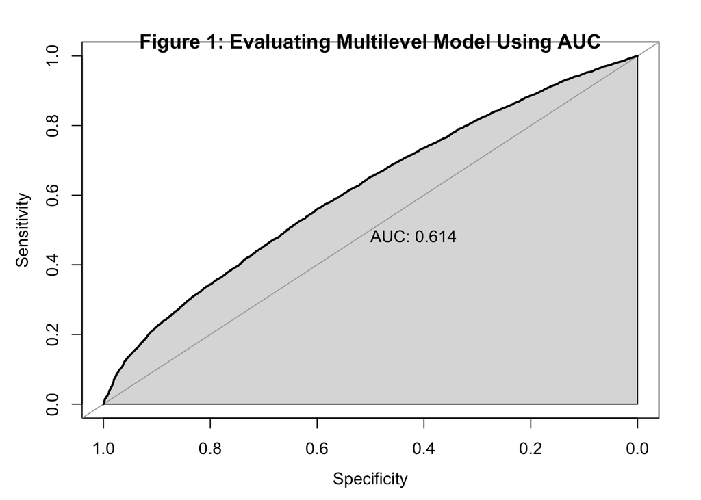

# Results

A summary table for the model is shown in **Table 3** in the *Model* section. The estimated proportion of voters in favour of Liberal Party in 2019 Canadian Federal Election is 0.2769 if voter turnover is 100% and all voters had voted. This is based on our poststratification analysis with a multilevel logistic regression model, which accounts for age, sex, education, and province. **Figure 2** shows the estimated percentage of voting shares of Liberal Party versus other parties. In reality, Liberal Party’s actual voting rate in 2019 Canadian Federal Election was 33.12%, while the estimated percentage in this study is 27.69%. By comparison, there is evidence that the actual result with lower turnout tends to be overrated compared to that with 100% turnout. If all eligible voters had voted, there is a risk that the Liberal Party may lose the election.

To be more specific, **Table 4** shows the percentage of voting shares of Liberal Party in 2019 by provinces, including both the actual results and the estimated results assuming 100% turnout. As we can see, except for the results in Alberta and Saskatchewan, the estimated results in all other provinces assuming 100% turnout are lower than the actual results in 2019. Evidently, voter turnout matters based on the model and results in this study.

To compute poststratification, I multiply the predicted percentage in each province by the respective population size of that province to get the weighted value, as shown in **Table 4**. The following step is to aggregate those weighted values, and then divide that aggregated value by the total population size.

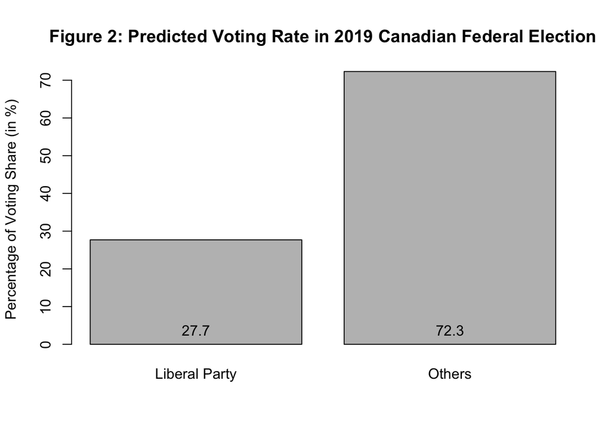

Table 4: Liberal Party’s Voting Rate by Province in 2019

| Province | Actual Percentage (1) | Predicted Percentage (2) | Population Size (3) | Weighted Value (2)*(3) |
| --- | --- | --- | --- | --- |
| Alberta | 13.7% | 14.63% | 1694 | 247.86 |
| British Columbia | 26.1% | 25.36% | 2466 | 625.49 |
| Manitoba | 26.2% | 23.58% | 1157 | 272.88 |
| New Brunswick | 37.6% | 29.73% | 1313 | 390.29 |
| Newfoundland and Labrador | 44.7% | 37.08% | 1072 | 397.50 |
| Nova Scotia | 41.4% | 35.06% | 1396 | 489.39 |
| Ontario | 41.4% | 32.21% | 5494 | 1769.39 |
| Prince Edward Island | 43.6% | 30.12% | 690 | 207.84 |
| Quebec | 34.2% | 27.95% | 3744 | 1046.45 |
| Saskatchewan | 11.6% | 11.74% | 1121 | 131.57 |

# Discussion

### Summary

The census data in this study is obtained from the 2017 Canada General Social Survey (GSS) administered by Statistics Canada, and the sample data is based on the survey responses collected from the Online 2019 Canadian Election Survey (CES). To conduct predictions, I ﬁrst build a multilevel logistic regression model to model the log odds of voters who will vote for Liberal Party. A set of demographic variables are used in this regression, where the level-one variables include *age, sex, education*, and the level-two variable is *province*. After that, a poststratiﬁcation technique is employed by first partitioning the sample into different cells based on province, followed by estimating the voting rate for Liberal Party within each cell, and finally weighting the cell-level estimates by their relative proportion in the population to generate the population-level estimate. Poststratiﬁcation is useful to correct the estimates of a non-representative sample. As mentioned in the *Data* section, the survey data is object to nonresponse bias given the nature of a voluntary survey. The potential low response rate could weaken the sample representativeness and induce biases on the results. Under this situation, the process of poststratiﬁcation helps to reduce biases and contributes to more precisely predicting the voting rate for Liberal Party in 2019 with an assumption that all voters had voted. However, the results are still biased because the census data is not strong enough, which will be discussed in detail in the following sub-section of *Weaknesses*.

### Conclusions

The percentage of voting share of Liberal Party is estimated to be 27.69% if all eligible voters had voted, which is lower than the actual result of 33.12% with a turnout of 67.0%. This outcome implies that voter turnout does play an importance role in the Canadian Federal Election results. Based on the model in this study, if the turnout is 100% instead of 67%, Liberal Party would gain a lower percentage of voting share in the 2019 election and pose a risk of losing the election. To conclude, a different rate of electoral participation is likely to change the election results. Moreover, a higher turnover indicates a greater level of democracy and stronger public confidence in a political system. Considering the importance of voter turnout, the government should pay attention to the causes of a declining turnout and think of what can be done to engage more voter participations, such as providing sufficient resources in elections and strengthening civic education at schools.

### Weaknesses

Regarding the datasets used for performing analyses, the GSS data that is used as census data could have several drawbacks. First, as mentioned in the *Data* section, the GSS data is obtained in 2017 while I am using it to employ poststratification in order to estimate the 2019 voting results. Although I have made adjustments on ages, but other variables are also likely to change from 2017 to 2019 and difficult to make precise adjustments, for example, education level. It is hard to say whether an individual keeps the original education level or pursues higher education between two years, while education level is an important demographic indicator that would affect voting choices. Consequently, the 2017 data may be misleading. Second, the number of observations of the GSS data is fewer than that of the CES data. Normally, the census data should be larger than the sample data, but this does not hold in this study. The smaller data size of the census data relative to the sample data could induce biases on the results. The problems of undercoverage and incomplete records of the GSS data could lower the predictive accuracy as well. In addition, referred to the *Model* section, the $R^2$ of the model is 0.073. This number indicates that the model can only explain 7.3% of the variance for the dependent variable, which is quite low. Also, the AUC of the model is 0.614, which is not good as well. A good classifier should have an AUC score of 0.8 or higher. Therefore, it may be concluded that the model is not strong enough to predict the voting results and need further improvements.

### Next Steps

First of all, I will do more research and try to obtain a better census data with stronger representativeness and larger data size. It will be better if the census data is able to reflect the up-to-date information of the population in 2019. Second, I will investigate a model with higher explanatory power. Specifically, I will start adding more independent variables to the regression model, such as household income and ethnicity, which are common demographic indicators as well. Last but not least, this study only estimates the 2019 Canadian Federal Election result for Liberal Party by assuming all eligible voters cast a ballot in the election. It is worthwhile continuing to estimate the voting results for other parties. By comparing those with the actual results, we can see how the story would have changed change if the voter turnout is 100%.

# References

Alexander (2019, Dec. 3). Rohan Alexander: Getting started with MRP. Retrieved from https://rohanalexander.com/posts/2019-12-04-getting_started_with_mrp/

Alexander, R. & Caetano, S. (2020). gss_cleaning.R [Source code].

Benjamin Rich (2020). table1: Tables of Descriptive Statistics in HTML. R package version 1.2.1. https://CRAN.R-project.org/package=table1

Consolidated federal laws of canada, Canada Elections Act. (2020, December 15). Retrieved December 22, 2020, from https://laws.justice.gc.ca/eng/acts/e-2.01/page-2.html

Douglas Bates, Martin Maechler, Ben Bolker, Steve Walker (2015). Fitting Linear Mixed-Effects Models Using lme4. Journal of Statistical Software, 67(1), 1-48.doi:10.18637/jss.v067.i01.

Fernando, J. (2020, November 18). R-Squared. Retrieved December 22, 2020, from https://www.investopedia.com/terms/r/r-squared.asp

Goodman, N. (2019, April 12). Here’s how we can get more people to vote in elections. Retrieved December 22, 2020, from https://www.toronto.com/opinion-story/9277815-here-s-how-we-can-get-more-people-to-vote-in-elections/

Hadley Wickham and Dana Seidel (2020). scales: Scale Functions for Visualization. R package version 1.1.1. https://CRAN.R-project.org/package=scales

Hadley Wickham, Jim Hester and Winston Chang (2020). devtools: Tools to Make Developing R Packages Easier. R package version 2.3.2. https://CRAN.R-project.org/package=devtools

Historical Voter Turnout in Canadian Federal Elections & Referenda, 1867-2019. (n.d.). Retrieved December 22, 2020, from https://www.sfu.ca/~aheard/elections/historical-turnout.html

Hodgetts, P. A., & Alexander, R. (2020, September 3). cesR: An R package for the Canadian Election Study. https://doi.org/10.31235/osf.io/a29h8

Joseph Larmarange (2020). labelled: Manipulating Labelled Data. R package version 2.7.0. https://CRAN.R-project.org/package=labelled

Lithwick, D., & Spano, S. (2008, September 15). Research publications - The Canadian Electoral System. Retrieved December 22, 2020, from https://lop.parl.ca/sites/PublicWebsite/default/en_CA/ResearchPublications/201381E

Lüdecke D (????). *sjPlot: Data Visualization for Statistics in Social Science*. R package version 2.8.6, <URL: https://CRAN.R-project.org/package=sjPlot>.

Narkhede, S. (2018, June 27). Understanding AUC - ROC Curve. Retrieved December 22, 2020, from https://towardsdatascience.com/understanding-auc-roc-curve-68b2303cc9c5

RStudio Team. (2020). RStudio: Integrated Development Environment for R. Boston, MA. Retrieved from http://www.rstudio.com/

Sagan, A. (2015, September 21). From free vacations to jail time: How some countries try to increase voter turnout | CBC News. Retrieved December 22, 2020, from https://www.cbc.ca/news/politics/canada-election-2015-voter-turnout-1.3230342

Statistics Canada. (2020). General social survey (GSS), 2017: Cycle 29, time use. [Public use microdata file and codebook]. Ottawa, ON: Statistics Canada. Retrieved from http://www.odesi.ca

Stephenson, Laura B; Harell, Allison; Rubenson, Daniel; Loewen, Peter John, 2020, “2019 Canadian Election Study - Online Survey”, https://doi.org/10.7910/DVN/DUS88V, Harvard Dataverse, V1

What are multilevel models and why should I use them? (n.d.). Retrieved December 22, 2020, from http://www.bristol.ac.uk/cmm/learning/multilevel-models/what-why.html

Wickham et al., (2019). Welcome to the tidyverse. Journal of Open Source Software, 4(43), 1686, https://doi.org/10.21105/joss.01686

Xavier Robin, Natacha Turck, Alexandre Hainard, Natalia Tiberti, Frédérique Lisacek, Jean-Charles Sanchez and Markus Müller (2011). pROC: an open-source package for R and S+ to analyze and compare ROC curves. BMC Bioinformatics, 12, p. 77. DOI: 10.1186/1471-2105-12-77 http://www.biomedcentral.com/1471-2105/12/77/